# PLN et EMtree pour REMMOA, sans spatial

```r
library(EMtree)
library(tidyverse)
library(grid)
library(gridExtra)
library(tidygraph)
library(ggraph)
library(ggbeeswarm)
```

# Chargement et mise en forme des données

- Lignes nulles
- Format des covariables
- Y_corr = comptages moyens par détection

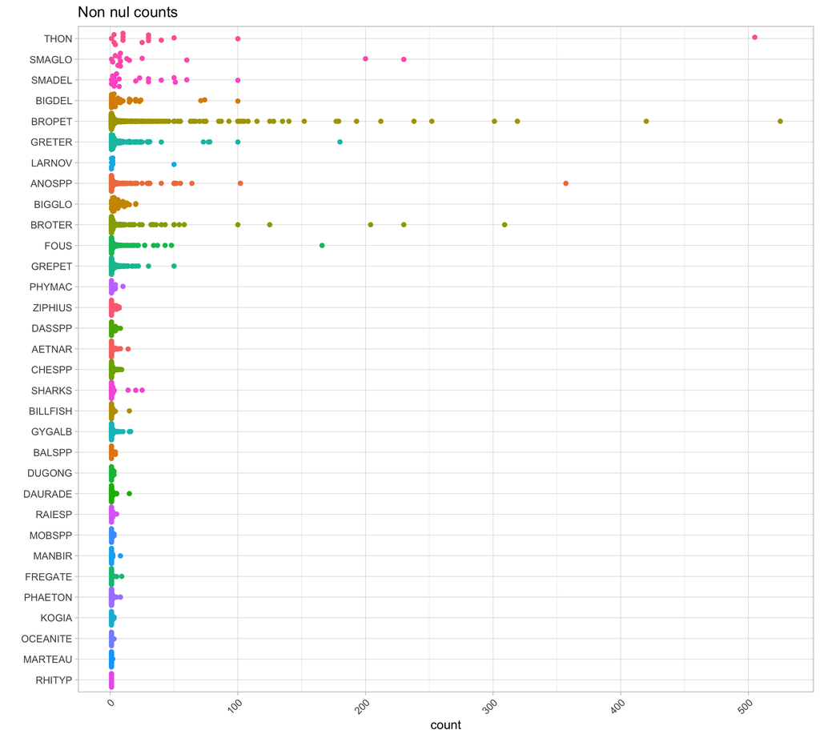

```r
setwd(WorkDir <- "/Users/raphaellemomal/these/Data_Oak_remmoa/REMMOA")
ShapeDir <- paste(WorkDir, "shape", sep = "/")
OutDir <- paste(WorkDir, "output", sep = "/")
theme_set(theme_light())
load(paste(OutDir, "20180620_PLN_REMMOANC.RData", sep = "/"))
colnames(X)[7:8]<-c("Xcart","Ycart")
null_index=which(rowSums(Y)==0)
Y=as.matrix(Y[-null_index,])
X=as.matrix(X[-null_index,])
N=as.matrix(N[-null_index,])

# correction des comptages par le nombre de détection
Y_corr=as.matrix(Y/N)
Y_corr[!is.finite(Y_corr)]<-0

Y %>%as_tibble() %>%  gather(species, count) %>%filter(count!=0) %>%  ggplot(aes(reorder(species,count), count, color=species))+geom_quasirandom()+labs(x="", title="Non nul counts")+ coord_flip()+
  theme(axis.text.x = element_text( angle = 45,hjust=1))+guides(color=FALSE)
```

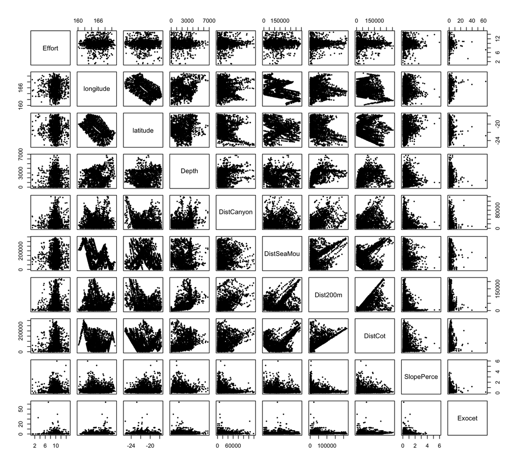

```r
# covariables numériques
X=data.frame(X)
X[,c(6:10,14:20)]<-apply(X[,c(6:10,14:20)], 2, function(x) as.numeric(x))

Xquanti=X[,c(6,9:10,14:20)] # sans Xcart et Ycart qui sont des transformations de longi et lati
plot(data.frame(Xquanti), pch=20, cex=0.5)
```

Fonctions utiles :

- Ajuster PLN avec des covariables de vec
- afficher le réseau après rééchantillonnage

```r
get_model<-function(data, vec){
  t1<-Sys.time()
  string<-paste(deparse(substitute(data)), paste(vec, collapse=" + "), sep=" ~ ")
  formula<-as.formula(string)
  mat = as.matrix(lm(formula, x=T)$x)
  model<-PLN(data ~ -1+mat)
  t2<-Sys.time()
  print(difftime(t2,t1))
  return(model)
}
get_network<-function(resample_output,title, data=Y, f=0.8){
  df<-freq_selec(resample_output$Pmat,p=ncol(data),f=f)
  graph<-draw_network(df,title, pal="dodgerblue3",
                              names=colnames(data), layout="nicely", size=3, curv=0.1)
  return(graph)
}
```

# Modèles PLN

Plusieurs modèles PLN ont été ajustés et stockés dans models.RData.

- m0 : ~ 1
- m1 : ~ 1 + SEA_STATE
- m2 : ~ 1 + Depth
- m3 : ~ 1 + SUBJECTIVE
- m4 : ~ 1 + Depth + SUBJECTIVE
- m5 : ~ 1 + SEA_STATE + SUBJECTIVE
- m6 : ~ 1 + SEA_STATE + Depth
- m7 : ~ 1 + SEA_STATE + Depth + SUBJECTIVE
- m8 : ~ 1 + longitude + latitude
- m9 : ~ 1 + longitude + latitude + Depth
- m10 : ~ 1 + longitude + latitude + SEA_STATE + Depth + SUBJECTIVE

Les modèles sont ajustés pour les données brutes Y (pas Y_corr). Le temps d’ajustement varie entre environ 30s et plus de deux minutes pour m8 et m9.

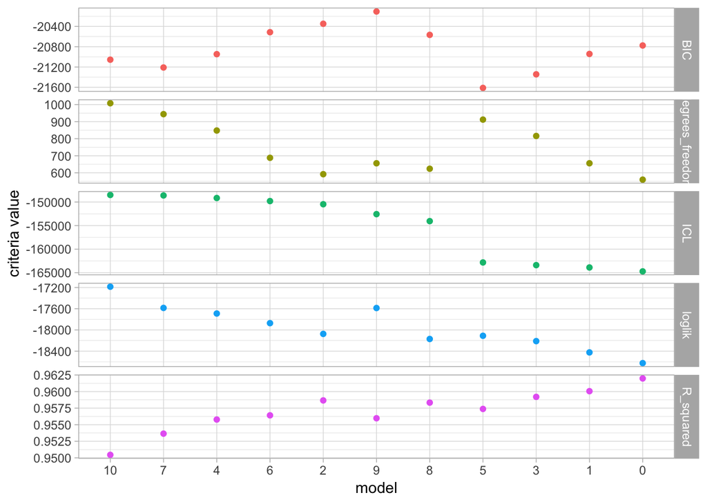

- Dans PLN on veut des grandes valeurs pour BIC, ICL et loglik
- les modèles 2, 4, et 6 comprennent “depth”, qui semble essentielle
- les coordonnées spatiales seules (modèle 8) montrent de belles performances
- cependant le temps d’ajustement est très conséquent (2.6min contre 28 à 56s pour les autres)
- le gain en ICL de 10 par rapport à 7 est négligeable
- depth+sea_state est meilleur que depth+spatial

Comparons les réseaux obtenus avec m0, m2 et m7 (pas d’ajustement spatial donc).

# Les réseaux

Les espèces surlignées en jaune dans les réseaux sont celles avec un score de betweenness important. La matrice d’offsets est construite à partir de la covariable “Effort”. Offset sample-specific.

- R0 : m0 et sans matrice d’effort. 5min, alpha mean = 0.6959584
- R_effort : m0 avec matrice d’efforts. 5.3min alpha mean = 0.710248
- R_depth : m2 et effort. 5.9min alpha mean = 0.7966224
- R_full : m7 et effort. 15.3min alpha mean = 0.9731524

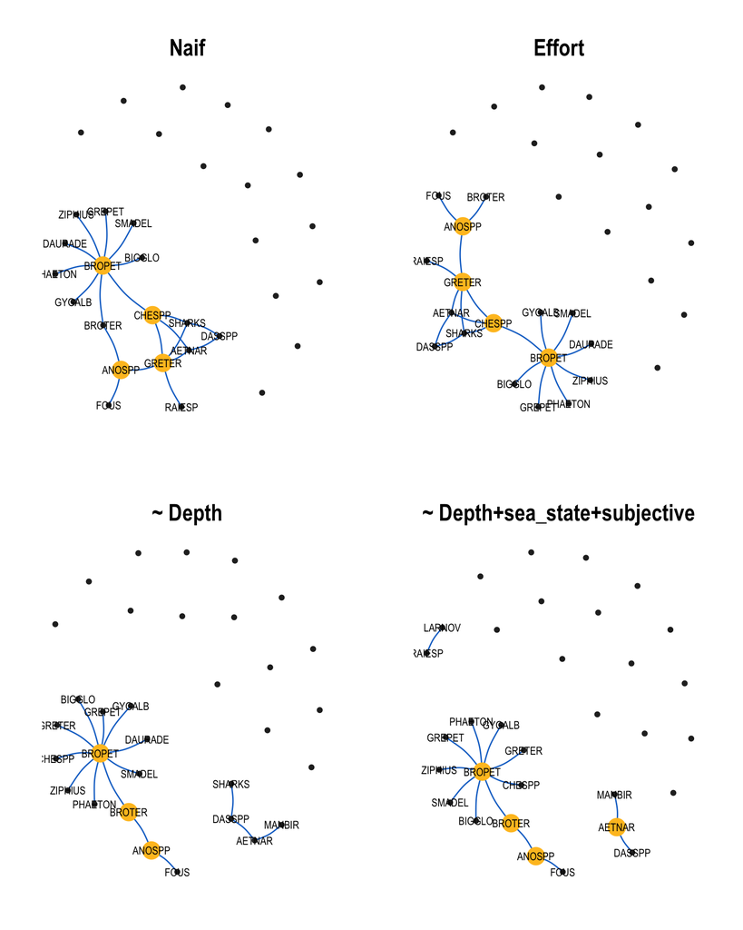

```r
load("Reseaux.RData")
graph0<-get_network(R0,"Naif")
graph_effort<-get_network(R_effort,"Effort")
graph_depth<-get_network(R_depth,"~ Depth")
graph_full<-get_network(R_full,"~ Depth+sea_state+subjective")

grid.arrange(graph0,graph_effort,graph_depth,graph_full,nrow=2, ncol=2)
```